# Take-home Exercise 4

In this take home exercise I will reveal the daily routines of two selected participants.

Heranshan Subramaniam https://www.linkedin.com/in/heranshan/ (School of Computing and Information Systems)https://scis.smu.edu.sg/  
2022-05-25

# Overview

In this take-home exercise, I will explore the daily life pattern of the least and most jovial participant with the use of the (ViSiElse)[https://cran.r-project.org/web/packages/ViSiElse/index.html] package.

# Getting Started

The required packages will be called with the following code chunk:

```r
packages = c('tidyverse', "ViSiElse", "lubridate")

for (p in packages){
  if(!require(p, character.only = T)){
    install.packages(p)
  }
  library(p,character.only = T)
}
```

# Importing Data

## Import Participant Data

The code chunk below will import *Participants.csv* from the data folder into R by using [`read_csv()`](https://readr.tidyverse.org/reference/read_delim.html) of [**readr**](https://readr.tidyverse.org/) package and save it as a tibble data frame called *Participant*.

```r
Participants <- read_csv("data/Participants.csv")
```

## Find Participant with the Highest and Lowest Joviality

```r
participantMaxJ <- Participants$participantId[Participants$joviality
                                              == max(Participants$joviality)]

participantMinJ <- Participants$participantId[Participants$joviality
                                              == min(Participants$joviality)]

selectedParticipants <- c(participantMinJ, participantMaxJ)

print(paste("Participant with max joviality is: ", participantMaxJ, ".",
            "Participant with min joviality is: ", participantMinJ, sep=""))
```

Participant with the highest joviality is participant 113 and participant with the lowest joviality is participant 758.

```r
print(subset(Participants, Participants$participantId %in% c(113,758)))
```

```
# A tibble: 2 x 7
  participantId householdSize haveKids   age educationLevel
          <dbl>         <dbl> <lgl>    <dbl> <chr>
1           113             2 FALSE       51 Graduate
2           758             3 TRUE        56 HighSchoolOrCollege
# ... with 2 more variables: interestGroup <chr>, joviality <dbl>
```

## Import Participant Log

```r
allFiles <- dir(path = "data/Activity Logs/", full.names = TRUE)

ParticipantsLog <- NULL

for (i in allFiles) {
  temp <- read_csv(i)

  temp <- subset(temp, temp$participantId %in% selectedParticipants)

  ParticipantsLog <- rbind(ParticipantsLog, temp)

  temp <- NULL
}
```

## Clean ParticipantsLog

```r
keep <- c("participantId", "timestamp", "currentMode", "sleepStatus")

ParticipantsLog <- ParticipantsLog[, keep]

Participant758 <- subset(ParticipantsLog, ParticipantsLog$participantId == 758)
Participant113<- subset(ParticipantsLog, ParticipantsLog$participantId == 113)

keep <- c("timestamp", "currentMode", "sleepStatus")
Participant758 <- ParticipantsLog[, keep]
Participant113 <- ParticipantsLog[, keep]
```

# Participant 758

## Data Prep for Participant 758

### Create minutes and date column

```r
Participant758 <- Participant758 %>%
  mutate(minutes = hour(timestamp)*60 + minute(timestamp))
```

```r
Participant758 <- Participant758 %>%
  mutate(date = date(timestamp))
```

```r
Participant758$status <- paste(Participant758$currentMode,
                               Participant758$sleepStatus, sep="-")
```

### Wake up

```r
Participant758Summary <- Participant758 %>%
  filter(status == "AtHome-Awake" & minutes != 0) %>%
  group_by(date) %>%
  summarise(minutes = min(minutes))

names(Participant758Summary) = c("Dates", "WakeUp")
```

```r
Participant758Summary$Sleep <- Participant758 %>%
  filter(status == "AtHome-Awake" & minutes != 0) %>%
  group_by(date) %>%
  summarise(minutes = max(minutes)) %>%
  select(minutes)
```

### Transport

```r
Participant758Summary$TransportDayStart <- Participant758 %>%
  filter(status == "Transport-Awake" & minutes != 0 & minutes <= 720) %>%
  group_by(date) %>%
  summarise(minutes = min(minutes)) %>%
  select(minutes)
```

```r
Participant758Summary$TransportEveningStart <- Participant758 %>%
  filter(status == "AtHome-Awake" & minutes != 0& minutes > 1035) %>%
  group_by(date) %>%
  summarise(minutes = min(minutes)) %>%
  select(minutes)
```

```r
Participant758Summary$TransportEveningStart <- Participant758 %>%
  filter(status == "Transport-Awake" & minutes != 0 & minutes > 720) %>%
  group_by(date) %>%
  summarise(minutes = min(minutes)) %>%
  select(minutes)
```

```r
Participant758Summary$Backhome <- Participant758 %>%
  filter(status == "AtHome-Awake" & minutes != 0) %>%
  group_by(date) %>%
  summarise(minutes = max(minutes)) %>%
  select(minutes)
```

```r
Participant758Summary$WorkStart <- Participant758 %>%
  filter(status == "AtWork-Awake" & minutes != 0) %>%
  group_by(date) %>%
  summarise(minutes = min(minutes)) %>%
  select(minutes)
```

```r
Participant758Summary$WorkEnd <- Participant758 %>%
  filter(status == "AtWork-Awake" & minutes != 0& minutes > 720) %>%
  group_by(date) %>%
  summarise(minutes = max(minutes)) %>%
  select(minutes)
```

```r
Participant758$status[Participant758$status == "AtRestaurant-PrepareToSleep"]
= "AtRestaurant-Awake"
```

### Lunch

```r
Lunch758 <- Participant758 %>%
  filter(status == "AtRestaurant-Awake" & minutes != 0 & date != "2023-05-24"
         & minutes <= 960) %>%
  group_by(date) %>%
  summarise(minutes = min(minutes))

names(Lunch758) = c("Dates", "LunchStart")
```

```r
Lunch758$LunchEnd<- Participant758 %>%
  filter(status == "AtRestaurant-Awake" & minutes != 0 & date != "2023-05-24"
         & minutes <= 960) %>%
  group_by(date) %>%
  summarise(minutes = max(minutes)) %>%
  select(minutes)
```

```r
Participant758Summary$LunchStart <- NA

Participant758Summary$LunchEnd <- NA
```

```r
names(Lunch758) = c("Dates", "LunchStart", "LunchEnd")
```

```r
Lunch758$LunchEnd <- as.data.frame(Lunch758$LunchEnd)[[1]]
```

```r
for (i in as.character(Lunch758$Dates)) {
  for (g in as.character(Participant758Summary$Dates)) {
    if (g == i) {
      Participant758Summary$LunchStart[as.character(Participant758Summary$Dates)
                                       == i] =
        Lunch758$LunchStart[as.character(Lunch758$Dates) == i]

      Participant758Summary$LunchEnd[as.character(Participant758Summary$Dates)
                                     == i] =
        Lunch758$LunchEnd[as.character(Lunch758$Dates) == i]
    }
  }
}
```

### Dinner

```r
Dinner758 <- Participant758 %>%
  filter(status == "AtRestaurant-Awake" & minutes != 0 & date != "2023-05-24"
         & minutes > 960) %>%
  group_by(date) %>%
  summarise(minutes = min(minutes))

names(Dinner758) = c("Dates", "DinnerStart")
```

```r
Dinner758$DinnerEnd<- Participant758 %>%
  filter(status == "AtRestaurant-Awake" & minutes != 0 & date != "2023-05-24"
         & minutes > 960) %>%
  group_by(date) %>%
  summarise(minutes = max(minutes)) %>%
  select(minutes)
```

```r
Participant758Summary$DinnerStart <- NA

Participant758Summary$DinnerEnd <- NA
```

```r
names(Dinner758) = c("Dates", "DinnerStart", "DinnerEnd")
```

```r
Dinner758$DinnerEnd <- as.data.frame(Dinner758$DinnerEnd)[[1]]
```

```r
for (i in as.character(Dinner758$Dates)) {
  for (g in as.character(Participant758Summary$Dates)) {
    if (g == i) {
      Participant758Summary$DinnerStart[as.character(Participant758Summary$Dates)
                                        == i] =
        Dinner758$DinnerStart[as.character(Dinner758$Dates) == i]

      Participant758Summary$DinnerEnd[as.character(Participant758Summary$Dates)
                                      == i] =
        Dinner758$DinnerEnd[as.character(Dinner758$Dates) == i]
    }
  }
}
```

### Recreation

```r
Participant758$status[Participant758$status == "AtRecreation-PrepareToSleep"]
= "AtRecreation-Awake"
```

```r
Recreation758 <- Participant758 %>%
  filter(status == "AtRecreation-Awake" & minutes != 0 & date != "2023-05-24")
%>%
  group_by(date) %>%
  summarise(minutes = min(minutes))

names(Recreation758) = c("Dates", "RecreationStart")
```

```r
Recreation758$RecreationEnd<- Participant758 %>%
  filter(status == "AtRecreation-Awake" & minutes != 0 & date != "2023-05-24" )
%>%
  group_by(date) %>%
  summarise(minutes = max(minutes)) %>%
  select(minutes)
```

```r
Participant758Summary$RecreationStart <- NA

Participant758Summary$RecreationEnd <- NA
```

```r
names(Recreation758) = c("Dates", "RecreationStart", "RecreationEnd")
```

```r
Recreation758$RecreationEnd <- as.data.frame(Recreation758$RecreationEnd)[[1]]
```

```r
for (i in as.character(Recreation758$Dates)) {
  for (g in as.character(Participant758Summary$Dates)) {
    if (g == i) {
      Participant758Summary$RecreationStart[
        as.character(Participant758Summary$Dates) == i] =
        Recreation758$RecreationStart[as.character(Recreation758$Dates) == i]

      Participant758Summary$RecreationEnd[
        as.character(Participant758Summary$Dates) == i] =
        Recreation758$RecreationEnd[as.character(Recreation758$Dates) == i]
    }
  }
}
```

### Prepare to Sleep

```r
PrepareToSleep<- Participant758 %>%
  filter(status == "AtHome-PrepareToSleep" & minutes != 0
         & date != "2023-05-24") %>%
  group_by(date) %>%
  summarise(minutes = max(minutes))
```

```r
Participant758Summary$PrepareToSleep <- NA
```

```r
for (i in as.character(PrepareToSleep$date)) {
  for (g in as.character(Participant758Summary$Dates)) {
    if (g == i) {
      Participant758Summary$PrepareToSleep[
        as.character(Participant758Summary$Dates) == i] =
        PrepareToSleep$minutes[as.character(PrepareToSleep$date) == i]

    }
  }
}
```

### Further Cleaning

```r
Participant758Summary$Sleep <-
  as.data.frame(Participant758Summary$Sleep)[[1]]

Participant758Summary$TransportDayStart <-
  as.data.frame(Participant758Summary$TransportDayStart)[[1]]

Participant758Summary$TransportEveningStart <- as.data.frame(Participant758Summary$TransportEveningStart)[[1]]

Participant758Summary$Backhome <-
  as.data.frame(Participant758Summary$Backhome)[[1]]

Participant758Summary$WorkStart <-
  as.data.frame(Participant758Summary$WorkStart)[[1]]

Participant758Summary$WorkEnd <-
  as.data.frame(Participant758Summary$WorkEnd)[[1]]
```

```r
Participant758Summary$StartSleep <- 0
```

```r
Clean758 <- as.data.frame(lapply(Participant758Summary, as.integer))
```

## Visibook

```r
p1 <- visielse(Clean758, informer = NULL)
```

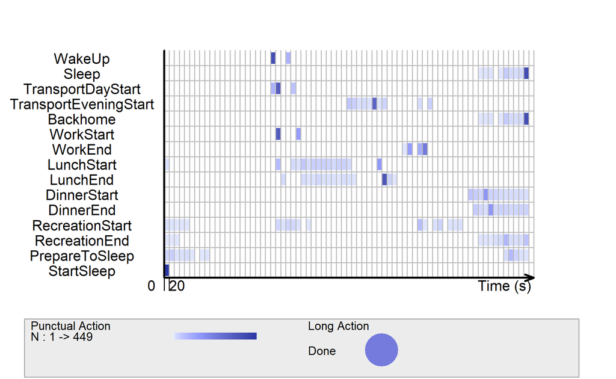

```r
b1 <- ConvertFromViSibook(p1@book)
```

```r
b1 <- b1[order(as.numeric(b1$showorder)), ] # order the data.frame
b1$label <- c("Wake Up", "Sleep", "Day Transport", "Evening Transport",
              "Reach Home", "Start Work", "End Work", "Start Lunch",
              "End Lunch", "Start Dinner", "End Dinner", "Start Recreation",
              "End Recreation", "Prepare To Sleep", "Start Sleeping")
```

```r
b1[16,] <- c("sleep", "Sleeping", "l", 1, "StartSleep", "WakeUp")
b1[17,] <- c("work", "Working", "l", 6, "WorkStart", "WorkEnd")
b1[18,] <- c("lunch", "Lunch break", "l", 7, "LunchStart", "LunchEnd")
b1[19,] <- c("dinner", "Dinner", "l", 10, "DinnerStart", "DinnerEnd")
b1$showorder <- c(2, NA, 3, 8, 10, 4, 6, NA, NA, NA, NA, 12, 13, 11, NA, 1,
                  5,7,9)
b1 <- b1[order(as.numeric(b1$showorder)), ]
```

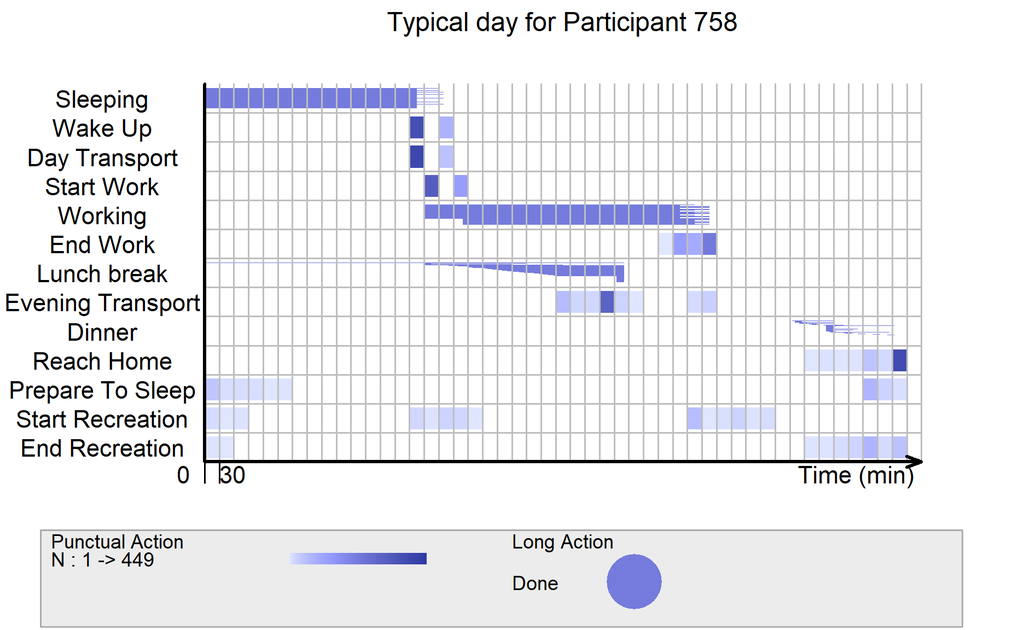

```r
v2 <- visielse(Clean758,
               book = b1,
               informer = NULL,
               doplot = F,
               pixel = 30)
plot(v2,
     vp0w = 0.7,
     unit.tps = "min",
     scal.unit.tps = 30,
     main = "Typical day for Participant 758")
```

### Comments

From the visualization it can be seen that the participant is very routine in terms of their when they wake up and head to bed. However, it can be seen that their lunch time is quite erratic. Working hours is very routine as well. One interesting observation is that there are times when the participant heads out to dinner. These occurrences are few and not routine. Furthermore, the start and end of their reacreation period is also not regular, indicating that it may differ depending on the day of the week.

# Participant 113

## Data Prep for Participant 113

### Create minutes and date column

```r
Participant113 <- Participant113 %>%
  mutate(minutes = hour(timestamp)*60 + minute(timestamp))
```

```r
Participant113 <- Participant113 %>%
  mutate(date = date(timestamp))
```

```r
Participant113$status <- paste(Participant113$currentMode,
                               Participant113$sleepStatus, sep="-")
```

### Wake up

```r
Participant113Summary <- Participant113 %>%
  filter(status == "AtHome-Awake" & minutes != 0) %>%
  group_by(date) %>%
  summarise(minutes = min(minutes))

names(Participant113Summary) = c("Dates", "WakeUp")
```

```r
Participant113Summary$Sleep <- Participant113 %>%
  filter(status == "AtHome-Awake" & minutes != 0) %>%
  group_by(date) %>%
  summarise(minutes = max(minutes)) %>%
  select(minutes)
```

### Transport

```r
Participant113Summary$TransportDayStart <- Participant113 %>%
  filter(status == "Transport-Awake" & minutes != 0 & minutes <= 720) %>%
  group_by(date) %>%
  summarise(minutes = min(minutes)) %>%
  select(minutes)
```

```r
Participant113Summary$TransportEveningStart <- Participant113 %>%
  filter(status == "AtHome-Awake" & minutes != 0& minutes > 1035) %>%
  group_by(date) %>%
  summarise(minutes = min(minutes)) %>%
  select(minutes)
```

```r
Participant113Summary$TransportEveningStart <- Participant113 %>%
  filter(status == "Transport-Awake" & minutes != 0 & minutes > 720) %>%
  group_by(date) %>%
  summarise(minutes = min(minutes)) %>%
  select(minutes)
```

```r
Participant113Summary$Backhome <- Participant113 %>%
  filter(status == "AtHome-Awake" & minutes != 0) %>%
  group_by(date) %>%
  summarise(minutes = max(minutes)) %>%
  select(minutes)
```

```r
Participant113Summary$WorkStart <- Participant113 %>%
  filter(status == "AtWork-Awake" & minutes != 0) %>%
  group_by(date) %>%
  summarise(minutes = min(minutes)) %>%
  select(minutes)
```

```r
Participant113Summary$WorkEnd <- Participant113 %>%
  filter(status == "AtWork-Awake" & minutes != 0& minutes > 720) %>%
  group_by(date) %>%
  summarise(minutes = max(minutes)) %>%
  select(minutes)
```

```r
Participant113$status[Participant113$status == "AtRestaurant-PrepareToSleep"]
= "AtRestaurant-Awake"
```

### Lunch

```r
Lunch113 <- Participant113 %>%
  filter(status == "AtRestaurant-Awake" & minutes != 0 & date != "2023-05-24"
         & minutes <= 960) %>%
  group_by(date) %>%
  summarise(minutes = min(minutes))

names(Lunch113) = c("Dates", "LunchStart")
```

```r
Lunch113$LunchEnd<- Participant113 %>%
  filter(status == "AtRestaurant-Awake" & minutes != 0 & date != "2023-05-24"
         & minutes <= 960) %>%
  group_by(date) %>%
  summarise(minutes = max(minutes)) %>%
  select(minutes)
```

```r
Participant113Summary$LunchStart <- NA

Participant113Summary$LunchEnd <- NA
```

```r
names(Lunch113) = c("Dates", "LunchStart", "LunchEnd")
```

```r
Lunch113$LunchEnd <- as.data.frame(Lunch113$LunchEnd)[[1]]
```

```r
for (i in as.character(Lunch113$Dates)) {
  for (g in as.character(Participant113Summary$Dates)) {
    if (g == i) {
      Participant113Summary$LunchStart[as.character(Participant113Summary$Dates)
                                       == i] =
        Lunch113$LunchStart[as.character(Lunch113$Dates) == i]

      Participant113Summary$LunchEnd[as.character(Participant113Summary$Dates)
                                     == i] =
        Lunch113$LunchEnd[as.character(Lunch113$Dates) == i]
    }
  }
}
```

### Dinner

```r
Dinner113 <- Participant113 %>%
  filter(status == "AtRestaurant-Awake" & minutes != 0 & date != "2023-05-24"
         & minutes > 960) %>%
  group_by(date) %>%
  summarise(minutes = min(minutes))

names(Dinner113) = c("Dates", "DinnerStart")
```

```r
Dinner113$DinnerEnd<- Participant113 %>%
  filter(status == "AtRestaurant-Awake" & minutes != 0 & date != "2023-05-24"
         & minutes > 960) %>%
  group_by(date) %>%
  summarise(minutes = max(minutes)) %>%
  select(minutes)
```

```r
Participant113Summary$DinnerStart <- NA

Participant113Summary$DinnerEnd <- NA
```

```r
names(Dinner113) = c("Dates", "DinnerStart", "DinnerEnd")
```

```r
Dinner113$DinnerEnd <- as.data.frame(Dinner113$DinnerEnd)[[1]]
```

```r
for (i in as.character(Dinner113$Dates)) {
  for (g in as.character(Participant113Summary$Dates)) {
    if (g == i) {
      Participant113Summary$DinnerStart[
        as.character(Participant113Summary$Dates) == i] =
        Dinner113$DinnerStart[as.character(Dinner113$Dates) == i]

      Participant113Summary$DinnerEnd[
        as.character(Participant113Summary$Dates) == i] =
        Dinner113$DinnerEnd[as.character(Dinner113$Dates) == i]
    }
  }
}
```

### Recreation

```r
Participant113$status[Participant113$status == "AtRecreation-PrepareToSleep"]
= "AtRecreation-Awake"
```

```r
Recreation113 <- Participant113 %>%
  filter(status == "AtRecreation-Awake" & minutes != 0
         & date != "2023-05-24") %>%
  group_by(date) %>%
  summarise(minutes = min(minutes))

names(Recreation113) = c("Dates", "RecreationStart")
```

```r
Recreation113$RecreationEnd<- Participant113 %>%
  filter(status == "AtRecreation-Awake" & minutes != 0
         & date != "2023-05-24" ) %>%
  group_by(date) %>%
  summarise(minutes = max(minutes)) %>%
  select(minutes)
```

```r
Participant113Summary$RecreationStart <- NA

Participant113Summary$RecreationEnd <- NA
```

```r
names(Recreation113) = c("Dates", "RecreationStart", "RecreationEnd")
```

```r
Recreation113$RecreationEnd <- as.data.frame(Recreation113$RecreationEnd)[[1]]
```

```r
for (i in as.character(Recreation113$Dates)) {
  for (g in as.character(Participant113Summary$Dates)) {
    if (g == i) {
      Participant113Summary$RecreationStart[
        as.character(Participant113Summary$Dates) == i] =
        Recreation113$RecreationStart[as.character(Recreation113$Dates) == i]

      Participant113Summary$RecreationEnd[
        as.character(Participant113Summary$Dates) == i] =
        Recreation113$RecreationEnd[as.character(Recreation113$Dates) == i]
    }
  }
}
```

### Prepare to Sleep

```r
PrepareToSleep<- Participant113 %>%
  filter(status == "AtHome-PrepareToSleep" & minutes != 0
         & date != "2023-05-24") %>%
  group_by(date) %>%
  summarise(minutes = max(minutes))
```

```r
Participant113Summary$PrepareToSleep <- NA
```

```r
for (i in as.character(PrepareToSleep$date)) {
  for (g in as.character(Participant113Summary$Dates)) {
    if (g == i) {
      Participant113Summary$PrepareToSleep[
        as.character(Participant113Summary$Dates) == i] =
        PrepareToSleep$minutes[as.character(PrepareToSleep$date) == i]

    }
  }
}
```

### Further Cleaning

```r
Participant113Summary$Sleep <-
  as.data.frame(Participant113Summary$Sleep)[[1]]

Participant113Summary$TransportDayStart <-
  as.data.frame(Participant113Summary$TransportDayStart)[[1]]

Participant113Summary$TransportEveningStart <- as.data.frame(Participant113Summary$TransportEveningStart)[[1]]

Participant113Summary$Backhome <-
  as.data.frame(Participant113Summary$Backhome)[[1]]

Participant113Summary$WorkStart <-
  as.data.frame(Participant113Summary$WorkStart)[[1]]

Participant113Summary$WorkEnd <-
  as.data.frame(Participant113Summary$WorkEnd)[[1]]
```

```r
Participant113Summary$StartSleep <- 0
```

```r
Clean113 <- as.data.frame(lapply(Participant113Summary, as.integer))
```

## Visibook

```r
p2 <- visielse(Clean113, informer = NULL)
```

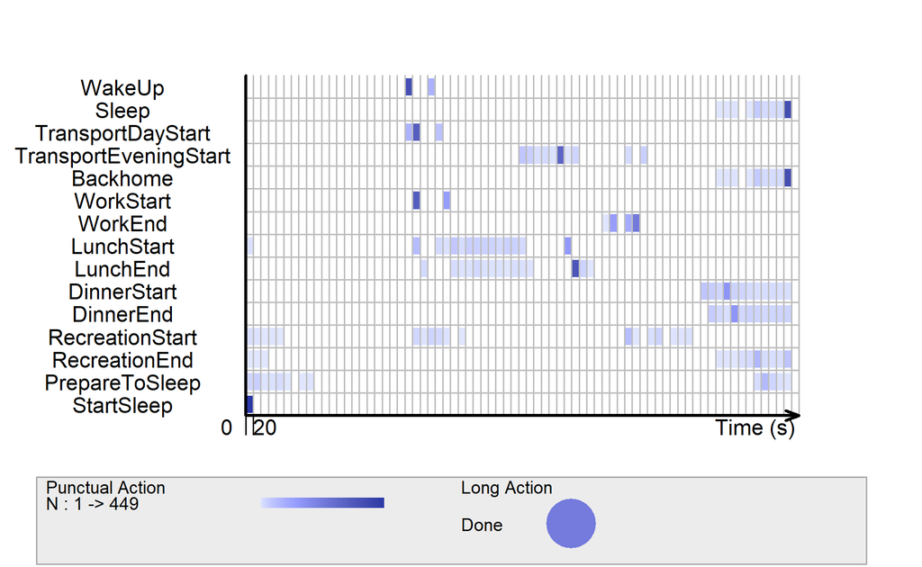

```r
b2 <- ConvertFromViSibook(p2@book)
```

```r
b2 <- b2[order(as.numeric(b2$showorder)), ] # order the data.frame
b2$label <- c("Wake Up", "Sleep", "Day Transport", "Evening Transport",
              "Reach Home", "Start Work", "End Work", "Start Lunch",
              "End Lunch", "Start Dinner", "End Dinner", "Start Recreation",
              "End Recreation", "Prepare To Sleep", "Start Sleeping")
```

```r
b2[16,] <- c("sleep", "Sleeping", "l", 1, "StartSleep", "WakeUp")
b2[17,] <- c("work", "Working", "l", 6, "WorkStart", "WorkEnd")
b2[18,] <- c("lunch", "Lunch break", "l", 7, "LunchStart", "LunchEnd")
b2[19,] <- c("dinner", "Dinner", "l", 10, "DinnerStart", "DinnerEnd")
b2$showorder <- c(2, NA, 3, 8, 10, 4, 6, NA, NA, NA, NA, 12, 13, 11, NA, 1,
                  5,7,9)
b2 <- b2[order(as.numeric(b2$showorder)), ]
```

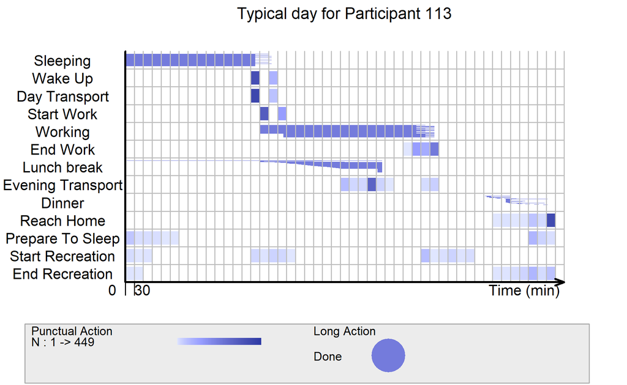

```r
v3 <- visielse(Clean113,
               book = b2,
               informer = NULL,
               doplot = F,
               pixel = 30)
plot(v3,
     vp0w = 0.7,
     unit.tps = "min",
     scal.unit.tps = 30,
     main = "Typical day for Participant 113")
```

### Comments

The visualization is almost identical to the previous participant. This will be discussed further in the next section.

# Comparison

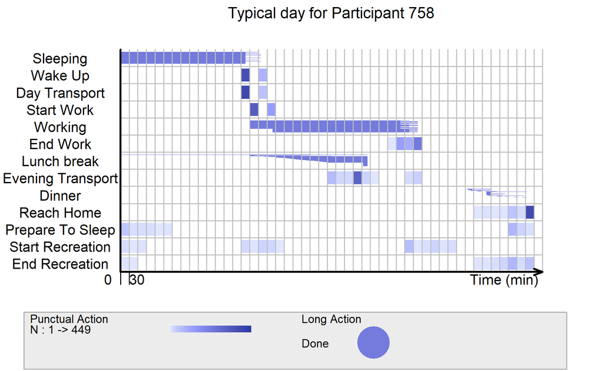

```r
plot(v2,
     vp0w = 0.7,
     unit.tps = "min",
     scal.unit.tps = 30,
     main = "Typical day for Participant 758")
```

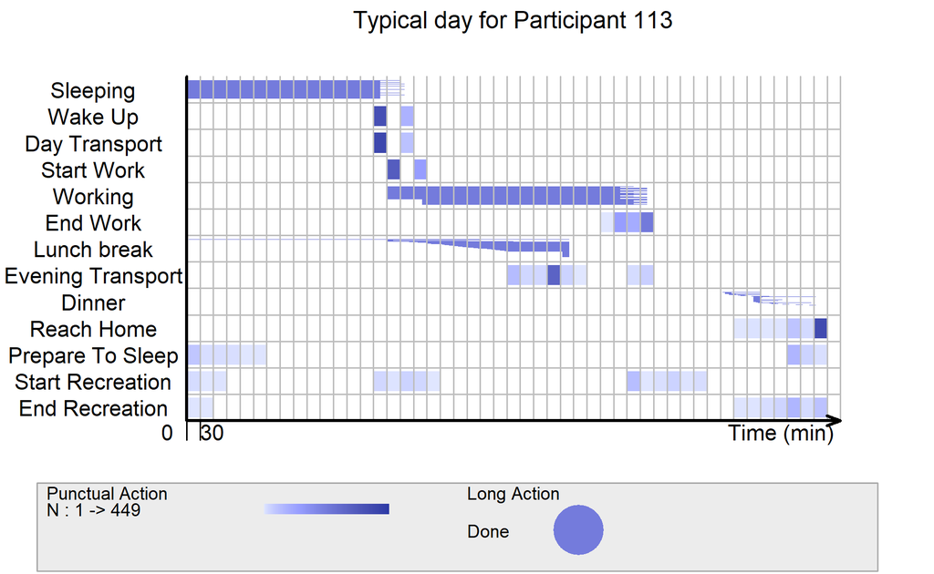

```r
plot(v3,
     vp0w = 0.7,
     unit.tps = "min",
     scal.unit.tps = 30,
     main = "Typical day for Participant 113")
```

## Comments:

There is not much difference seen in the graphs of both participants. This may be due to multiple reasons:

1. There may have been an error in the way the data was extracted from the journal
2. The manner in which the data was cleaned was too prescriptive, forcing the timing upon the activites
3. The difference in joviality did not play a large factor in the daily lives of the participants
- There may be other more influential attibutes such as age that may show a greater disparity in terms of activity

# Other Feedback

On hindsight the ViSiElse library may not have been the most effective for this visualization as it is very rigid in terms of the data formatting required. This led to extensive hours of data cleaning before any visualization could be acheived to check if the progress made was on the right track.